# KPMB Data Analytics Virtual Experience

By: Nugroho Budianggoro 02/12/2021 Jakarta, Indonesia

Checking parts of data that need cleaning.

```r
# Import
library("readxl")
library("dplyr")
library("ggplot2")
library("lubridate")
library("janitor")
library("tibble")

# Set path
path <- "KPMG_VI_New_raw_data_update_final.xlsx"

# Get sheets name
excel_sheets(path = path)
```

```
[1] "Title Sheet"         "Transactions"        "NewCustomerList"     "CustomerDemographic" "CustomerAddress"
```

Define common procedures

```r
stats_cat <- function(col){
    num_row <- nrow(col)
    num_na <- sum(is.na(col))
    num_dup <- sum(duplicated(col))
    num_unique <- nrow(unique(col))

    Variable <- c("Number of Rows", "Number of NAs", "Number of Duplicates", "Number of Uniques")
    Value <- c(num_row, num_na, num_dup, num_unique)
    res <- data.frame(Variable, Value)
    return(res)
}

stats_num <- function(col){
    num_row <- nrow(col)
    min <- min(col, na.rm = TRUE)
    max <- max(col, na.rm=TRUE)
    num_na <- sum(is.na(col))
    num_dup <- sum(duplicated(col))
    num_unique <- nrow(unique(col))

    Variable <- c("Number of Rows", "Min", "Max", "Number of NAs", "Number of Duplicates", "Number of Uniques")
    Value <- c(num_row, min, max, num_na, num_dup, num_unique)
    res <- data.frame(Variable, Value)
    return(res)
}

stats_date <- function(col){
    num_row <- nrow(col)
    num_na <- sum(is.na(col))
    num_dup <- sum(duplicated(col))
    num_unique <- nrow(unique(col))

    Variable <- c("Number of Rows", "Number of NAs", "Number of Duplicates", "Number of Uniques")
    Value <- c(num_row, num_na, num_dup, num_unique)
    res <- data.frame(Variable, Value)
    return(res)
}
```

TRANSACTIONS sheet

```r
df_trans <- read_excel(path, sheet = "Transactions", skip = 1)
head(df_trans)
```

| transaction_id | product_id | customer_id | transaction_date | online_order | order_status | brand | product_line | product_class | product_size | list_price | standard_cost | product_first_sold_date |
| --- | --- | --- | --- | --- | --- | --- | --- | --- | --- | --- | --- | --- |
| 1 | 2 | 2950 | 2017-02-25 | FALSE | Approved | Solex | Standard | medium | medium | 71.49 | 53.62 | 41245 |
| 2 | 3 | 3120 | 2017-05-21 | TRUE | Approved | Trek Bicycles | Standard | medium | large | 2091.47 | 388.92 | 41701 |
| 3 | 37 | 402 | 2017-10-16 | FALSE | Approved | OHM Cycles | Standard | low | medium | 1793.43 | 248.82 | 36361 |
| 4 | 88 | 3135 | 2017-08-31 | FALSE | Approved | Norco Bicycles | Standard | medium | medium | 1198.46 | 381.10 | 36145 |
| 5 | 78 | 787 | 2017-10-01 | TRUE | Approved | Giant Bicycles | Standard | medium | large | 1765.30 | 709.48 | 42226 |
| 6 | 25 | 2339 | 2017-03-08 | TRUE | Approved | Giant Bicycles | Road | medium | medium | 1538.99 | 829.65 | 39031 |

```r
NA
```

```r
# Change columns data types
to_chr <- c("transaction_id", "product_id", "customer_id")
df_trans[to_chr] <- sapply(df_trans[to_chr], as.character)

df_trans["product_first_sold_date"] <- excel_numeric_to_date(df_trans$product_first_sold_date)
```

TRANSACTIONS sheet: transaction_id

```r
stats_cat(df_trans["transaction_id"])
```

| Variable | Value |
| --- | --- |
| Number of Rows | 20000 |
| Number of NAs | 0 |
| Number of Duplicates | 0 |
| Number of Uniques | 20000 |

TRANSACTIONS sheet: product_id

```r
stats_cat(df_trans["product_id"])
```

| Variable | Value |
| --- | --- |
| Number of Rows | 20000 |
| Number of NAs | 0 |
| Number of Duplicates | 19899 |
| Number of Uniques | 101 |

```r
# Unique values
uniques <- unique(df_trans["product_id"])
pull(uniques, product_id)
```

```
  [1] "2"   "3"   "37"  "88"  "78"  "25"  "22"  "15"  "67"  "12"  "5"   "61"  "35"  "16"  "79"  "33"  "54"  "27"  "82"  "89"  "64"  "19"  "72"
 [24] "91"  "1"   "99"  "0"   "92"  "14"  "44"  "76"  "46"  "55"  "66"  "81"  "86"  "32"  "77"  "96"  "6"   "47"  "94"  "93"  "60"  "28"  "4"
 [47] "38"  "56"  "58"  "50"  "80"  "87"  "84"  "21"  "31"  "62"  "17"  "73"  "45"  "49"  "95"  "18"  "70"  "26"  "39"  "36"  "98"  "75"  "42"
 [70] "20"  "24"  "53"  "65"  "29"  "11"  "10"  "7"   "41"  "9"   "69"  "90"  "97"  "100" "74"  "71"  "34"  "57"  "23"  "51"  "59"  "63"  "40"
 [93] "8"   "13"  "30"  "48"  "68"  "83"  "43"  "52"  "85"
```

TRANSACTIONS sheet: customer_id

```r
stats_cat(df_trans["customer_id"])
```

| Variable | Value |
| --- | --- |
| Number of Rows | 20000 |
| Number of NAs | 0 |
| Number of Duplicates | 16506 |
| Number of Uniques | 3494 |

TRANSACTIONS sheet: transaction_date

```r
stats_date(df_trans["transaction_date"])
```

| Variable | Value |
| --- | --- |
| Number of Rows | 20000 |
| Number of NAs | 0 |
| Number of Duplicates | 19636 |
| Number of Uniques | 364 |

```r
NA
```

```r
min <- min(df_trans$transaction_date, na.rm = TRUE)
max <- max(df_trans$transaction_date, na.rm = TRUE)
data.frame(min, max)
```

| min | max |
| --- | --- |
| 2017-01-01 | 2017-12-30 |

```r
NA
```

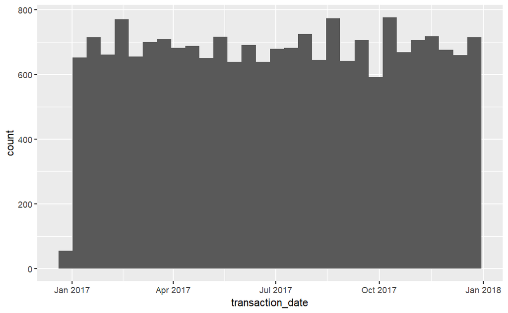

```r
ggplot(df_trans, aes(x=transaction_date)) + geom_histogram()
```

TRANSACTIONS sheet: online_order

```r
stats_cat(df_trans["online_order"])
```

| Variable | Value |
| --- | --- |
| Number of Rows | 20000 |
| Number of NAs | 360 |
| Number of Duplicates | 19997 |
| Number of Uniques | 3 |

```r
unique(df_trans["online_order"])
```

| online_order |
| --- |
| FALSE |
| TRUE |
| NA |

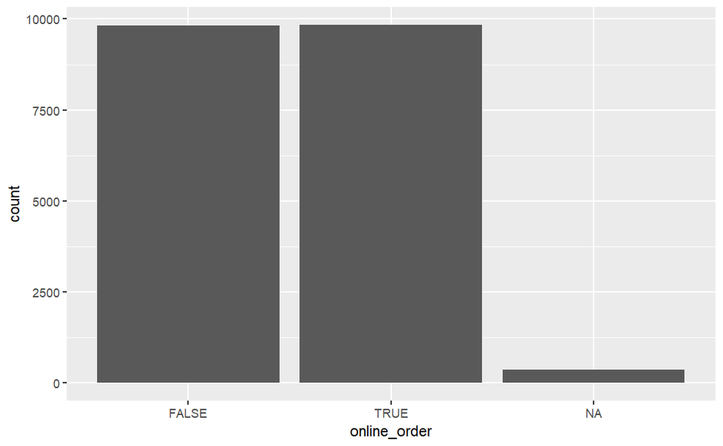

```r
ggplot(df_trans["online_order"], aes(x=online_order)) + geom_bar()
```

TRANSACTIONS sheet: order_status

```r
stats_cat(df_trans["order_status"])
```

| Variable | Value |
| --- | --- |
| Number of Rows | 20000 |
| Number of NAs | 0 |
| Number of Duplicates | 19998 |
| Number of Uniques | 2 |

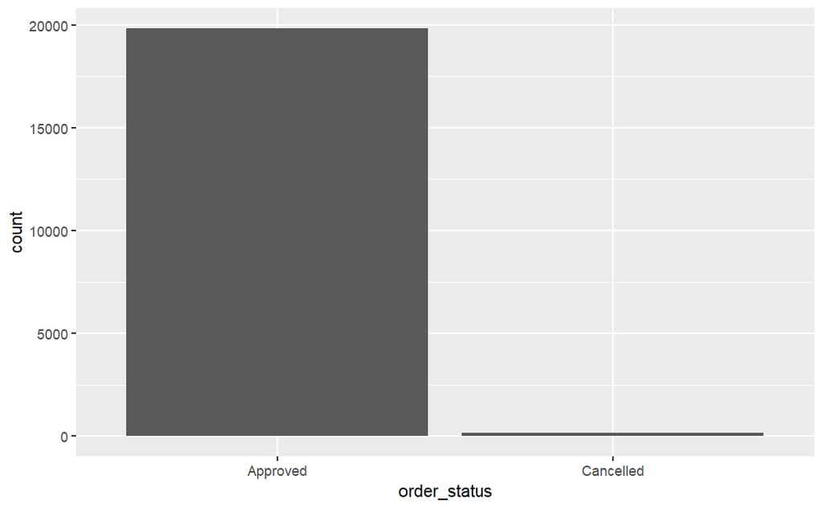

```r
ggplot(df_trans["order_status"], aes(x=order_status)) + geom_bar()
```

TRANSACTIONS sheet: brand

```r
stats_cat(df_trans["brand"])
```

| Variable | Value |
| --- | --- |
| Number of Rows | 20000 |
| Number of NAs | 197 |
| Number of Duplicates | 19993 |
| Number of Uniques | 7 |

```r
unique(df_trans["brand"])
```

| brand |
| --- |
| Solex |
| Trek Bicycles |
| OHM Cycles |
| Norco Bicycles |
| Giant Bicycles |
| WeareA2B |
| NA |

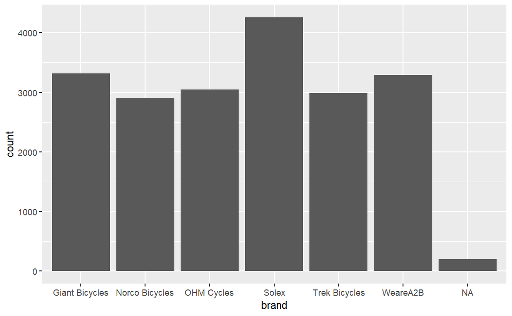

```r
ggplot(df_trans["brand"], aes(x=brand)) + geom_bar()
```

TRANSACTIONS sheet: product_line

```r
stats_cat(df_trans["product_line"])
```

| Variable | Value |
| --- | --- |
| Number of Rows | 20000 |
| Number of NAs | 197 |
| Number of Duplicates | 19995 |
| Number of Uniques | 5 |

```r
unique(df_trans["product_line"])
```

| product_line |
| --- |
| Standard |
| Road |
| Mountain |
| Touring |
| NA |

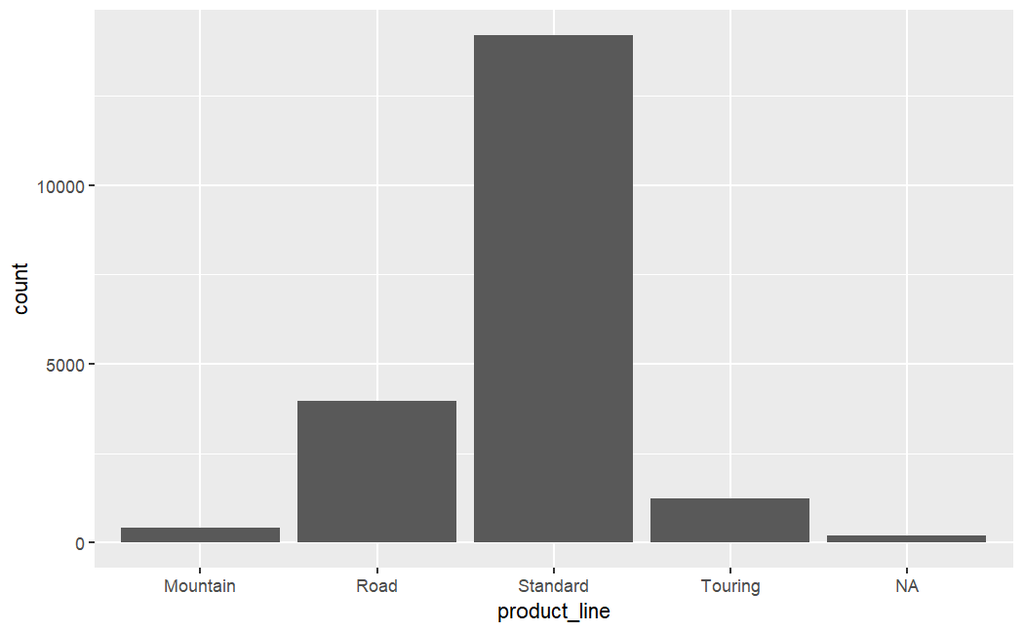

```r
ggplot(df_trans["product_line"], aes(x=product_line)) + geom_bar()
```

TRANSACTIONS sheet: product_size

```r
stats_cat(df_trans["product_size"])
```

| Variable | Value |
| --- | --- |
| Number of Rows | 20000 |
| Number of NAs | 197 |
| Number of Duplicates | 19996 |
| Number of Uniques | 4 |

```r
unique(df_trans["product_size"])
```

| product_size |
| --- |
| medium |
| large |
| small |
| NA |

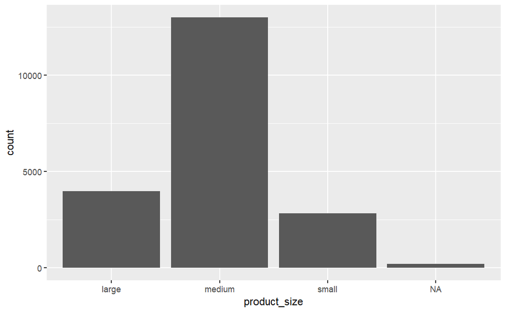

```r
ggplot(df_trans["product_size"], aes(x=product_size)) + geom_bar()
```

TRANSACTIONS sheet: list_price

```r
stats_num(df_trans["list_price"])
```

| Variable | Value |
| --- | --- |
| Number of Rows | 20000.00 |
| Min | 12.01 |
| Max | 2091.47 |
| Number of NAs | 0.00 |
| Number of Duplicates | 19704.00 |
| Number of Uniques | 296.00 |

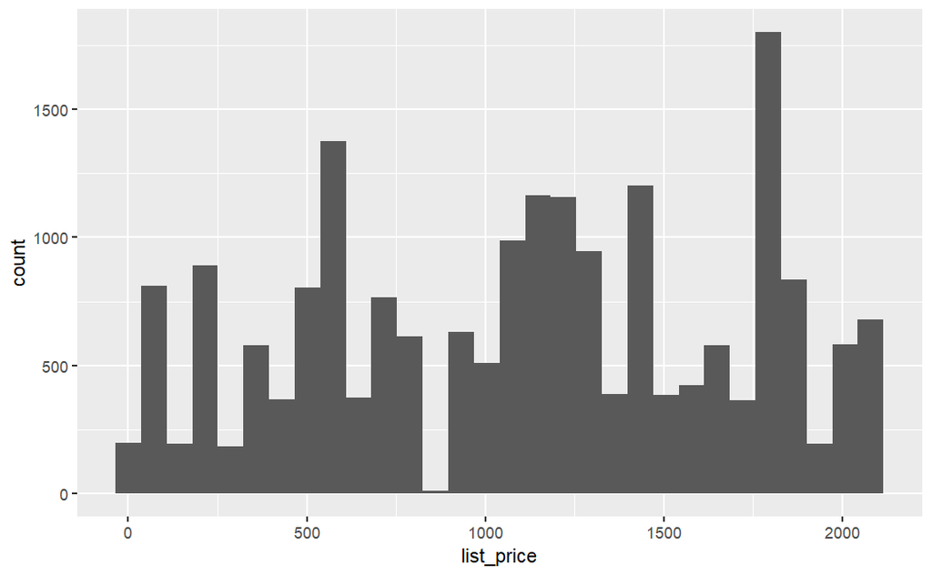

```r
ggplot(df_trans, aes(x=list_price)) + geom_histogram()
```

```r
# Check to see if there is a character value in this numeric column
vec <- pull(df_trans, list_price )
sum(is.na(as.numeric(as.character(vec))))
```

```
[1] 0
```

TRANSACTIONS sheet: standard_cost

```r
stats_num(df_trans["standard_cost"])
```

| Variable | Value |
| --- | --- |
| Number of Rows | 20000.00 |
| Min | 7.21 |
| Max | 1759.85 |
| Number of NAs | 197.00 |
| Number of Duplicates | 19896.00 |
| Number of Uniques | 104.00 |

```
Warning: Removed 197 rows containing non-finite values (stat_bin).
```

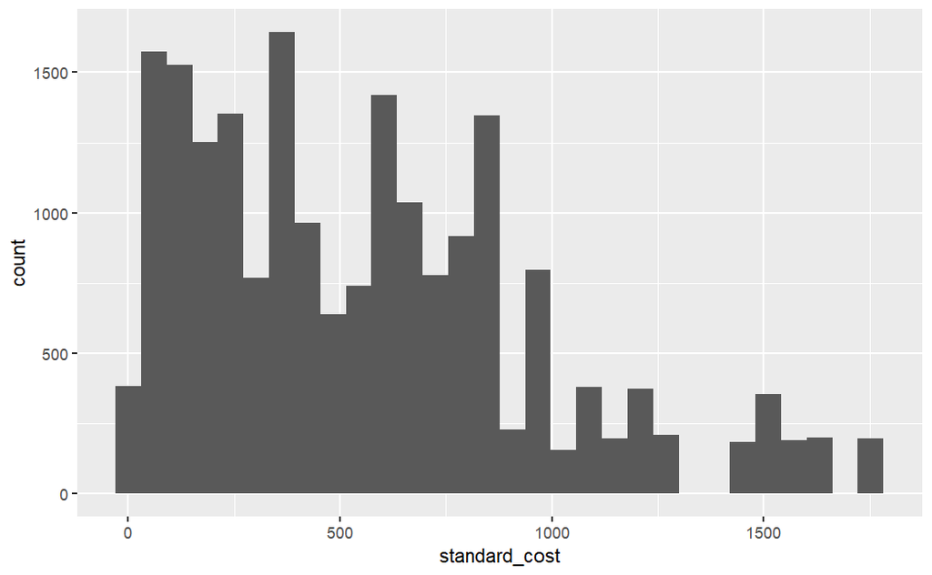

```r
ggplot(df_trans, aes(x=standard_cost)) + geom_histogram()
```

```r
# Check to see if there is a character value in this numeric column
vec <- pull(df_trans, standard_cost )
sum(is.na(as.numeric(as.character(vec))))
```

```
[1] 197
```

```r
# Check to see if there is a character value in this numeric column
vec <- pull(df_trans, standard_cost )
sum(is.na(as.numeric(as.character(vec))))
```

```
[1] 197
```

TRANSACTIONS sheet: product_first_sold_date

```r
stats_date(df_trans["product_first_sold_date"])
```

| Variable | Value |
| --- | --- |
| Number of Rows | 20000 |
| Number of NAs | 197 |
| Number of Duplicates | 19899 |
| Number of Uniques | 101 |

```r
min <- min(df_trans$product_first_sold_date, na.rm = TRUE)
max <- max(df_trans$product_first_sold_date, na.rm = TRUE)
data.frame(min, max)
```

| min | max |
| --- | --- |
| 1991-01-21 | 2016-12-06 |

NEWCUSTOMERLIST sheet

```r
df_nc <- read_excel(path, sheet = "NewCustomerList", skip = 1)
```

```
* `` -> ...17
* `` -> ...18
* `` -> ...19
* `` -> ...20
* `` -> ...21
```

```r
head(df_nc)
```

| first_name | last_name | gender | past_3_years_bike_related_purchases | DOB | job_title | job_industry_category | wealth_segment | deceased_indicator | owns_car | tenure | address | postcode | state | country | property_valuation | ...17 | ...18 | ...19 | ...20 | ...21 | Rank | Value |
| --- | --- | --- | --- | --- | --- | --- | --- | --- | --- | --- | --- | --- | --- | --- | --- | --- | --- | --- | --- | --- | --- | --- |
| Chickie | Brister | Male | 86 | 1957-07-12 | General Manager | Manufacturing | Mass Customer | N | Yes | 14 | 45 Shopko Center | 4500 | QLD | Australia | 6 | 0.46 | 0.575 | 0.71875 | 0.6109375 | 1 | 1 | 1.718750 |
| Morly | Genery | Male | 69 | 1970-03-22 | Structural Engineer | Property | Mass Customer | N | No | 16 | 14 Mccormick Park | 2113 | NSW | Australia | 11 | 0.93 | 0.930 | 1.16250 | 0.9881250 | 1 | 1 | 1.718750 |
| Ardelis | Forrester | Female | 10 | 27269 | Senior Cost Accountant | Financial Services | Affluent Customer | N | No | 10 | 5 Colorado Crossing | 3505 | VIC | Australia | 5 | 0.42 | 0.420 | 0.42000 | 0.4200000 | 1 | 1 | 1.718750 |
| Lucine | Stutt | Female | 64 | 1979-01-28 | Account Representative III | Manufacturing | Affluent Customer | N | Yes | 5 | 207 Annamark Plaza | 4814 | QLD | Australia | 1 | 0.98 | 1.225 | 1.22500 | 1.2250000 | 4 | 4 | 1.703125 |
| Melinda | Hadlee | Female | 34 | 1965-09-21 | Financial Analyst | Financial Services | Affluent Customer | N | No | 19 | 115 Montana Place | 2093 | NSW | Australia | 9 | 1.08 | 1.080 | 1.35000 | 1.3500000 | 4 | 4 | 1.703125 |
| Druci | Brandli | Female | 39 | 1951-04-29 | Assistant Media Planner | Entertainment | High Net Worth | N | Yes | 22 | 89105 Pearson Terrace | 4075 | QLD | Australia | 7 | 0.90 | 1.125 | 1.12500 | 1.1250000 | 6 | 6 | 1.671875 |

```r
NA
```

```r
names(df_nc)
```

```
 [1] "first_name"                          "last_name"                           "gender"
 [4] "past_3_years_bike_related_purchases" "DOB"                                 "job_title"
 [7] "job_industry_category"               "wealth_segment"                      "deceased_indicator"
[10] "owns_car"                            "tenure"                              "address"
[13] "postcode"                            "state"                               "country"
[16] "property_valuation"                  "...17"                               "...18"
[19] "...19"                               "...20"                               "...21"
[22] "Rank"                                "Value"
```

```r
# Change columns data types
to_num <- c("past_3_years_bike_related_purchases", "property_valuation")
df_nc[to_num] <- sapply(df_nc[to_num], as.numeric)
df_nc <- mutate(df_nc, DOB = as.Date(DOB, format = "%Y-%m-%d"))
```

NEWCUSTOMERLIST sheet: check for person duplicates

```r
df_nc$check_dup <- paste(df_ncl$first_name, df_ncl$last_name, df_ncl$DOB)
head(df_nc)
```

| first_name | last_name | gender | past_3_years_bike_related_purchases | DOB | job_title | job_industry_category | wealth_segment | deceased_indicator | owns_car | tenure | address | postcode | state | country | property_valuation | ...17 | ...18 | ...19 | ...20 | ...21 | Rank | Value | check_dup |
| --- | --- | --- | --- | --- | --- | --- | --- | --- | --- | --- | --- | --- | --- | --- | --- | --- | --- | --- | --- | --- | --- | --- | --- |
| Chickie | Brister | Male | 86 | 1957-07-12 | General Manager | Manufacturing | Mass Customer | N | Yes | 14 | 45 Shopko Center | 4500 | QLD | Australia | 6 | 0.46 | 0.575 | 0.71875 | 0.6109375 | 1 | 1 | 1.718750 | Chickie Brister 1957-07-12 |
| Morly | Genery | Male | 69 | 1970-03-22 | Structural Engineer | Property | Mass Customer | N | No | 16 | 14 Mccormick Park | 2113 | NSW | Australia | 11 | 0.93 | 0.930 | 1.16250 | 0.9881250 | 1 | 1 | 1.718750 | Morly Genery 1970-03-22 |
| Ardelis | Forrester | Female | 10 |  | Senior Cost Accountant | Financial Services | Affluent Customer | N | No | 10 | 5 Colorado Crossing | 3505 | VIC | Australia | 5 | 0.42 | 0.420 | 0.42000 | 0.4200000 | 1 | 1 | 1.718750 | Ardelis Forrester 27269 |
| Lucine | Stutt | Female | 64 | 1979-01-28 | Account Representative III | Manufacturing | Affluent Customer | N | Yes | 5 | 207 Annamark Plaza | 4814 | QLD | Australia | 1 | 0.98 | 1.225 | 1.22500 | 1.2250000 | 4 | 4 | 1.703125 | Lucine Stutt 1979-01-28 |
| Melinda | Hadlee | Female | 34 | 1965-09-21 | Financial Analyst | Financial Services | Affluent Customer | N | No | 19 | 115 Montana Place | 2093 | NSW | Australia | 9 | 1.08 | 1.080 | 1.35000 | 1.3500000 | 4 | 4 | 1.703125 | Melinda Hadlee 1965-09-21 |
| Druci | Brandli | Female | 39 | 1951-04-29 | Assistant Media Planner | Entertainment | High Net Worth | N | Yes | 22 | 89105 Pearson Terrace | 4075 | QLD | Australia | 7 | 0.90 | 1.125 | 1.12500 | 1.1250000 | 6 | 6 | 1.671875 | Druci Brandli 1951-04-29 |

```r
stats_cat(df_nc["check_dup"])
```

| Variable | Value |
| --- | --- |
| Number of Rows | 1000 |
| Number of NAs | 0 |
| Number of Duplicates | 0 |
| Number of Uniques | 1000 |

NEWCUSTOMERLIST sheet: first_name

```r
stats_cat(df_nc["first_name"])
```

| Variable | Value |
| --- | --- |
| Number of Rows | 1000 |
| Number of NAs | 0 |
| Number of Duplicates | 60 |
| Number of Uniques | 940 |

NEWCUSTOMERLIST sheet: last_name

```r
stats_cat(df_nc["last_name"])
```

| Variable | Value |
| --- | --- |
| Number of Rows | 1000 |
| Number of NAs | 29 |
| Number of Duplicates | 38 |
| Number of Uniques | 962 |

NEWCUSTOMERLIST sheet: gender

```r
stats_cat(df_nc["gender"])
```

| Variable | Value |
| --- | --- |
| Number of Rows | 1000 |
| Number of NAs | 0 |
| Number of Duplicates | 997 |
| Number of Uniques | 3 |

```r
unique(df_nc["gender"])
```

| gender |
| --- |
| Male |
| Female |
| U |

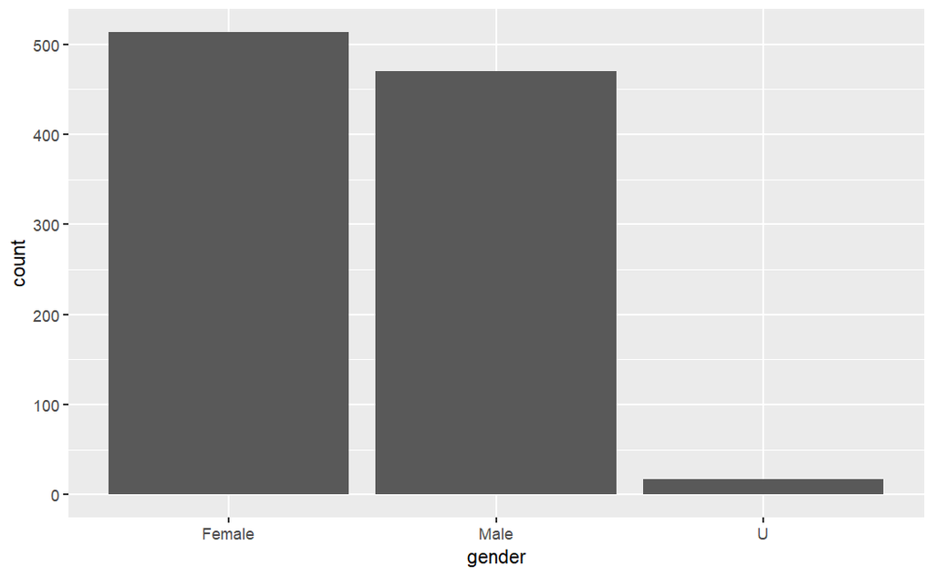

```r
ggplot(df_nc, aes(x=gender)) + geom_bar()
```

```r
as.data.frame(table(df_nc["gender"]))
```

| Var1 | Freq |
| --- | --- |
| Female | 513 |
| Male | 470 |
| U | 17 |

NEWCUSTOMERLIST sheet: past_3_years_bike_related_purchases

```r
stats_num(df_nc["past_3_years_bike_related_purchases"])
```

| Variable | Value |
| --- | --- |
| Number of Rows | 1000 |
| Min | 0 |
| Max | 99 |
| Number of NAs | 0 |
| Number of Duplicates | 900 |
| Number of Uniques | 100 |

```r
# Check if there is a non-numeric value in a numeric column
vec <- pull(df_nc, past_3_years_bike_related_purchases)
sum((is.na(as.numeric(as.character(vec)))))
```

```
[1] 0
```

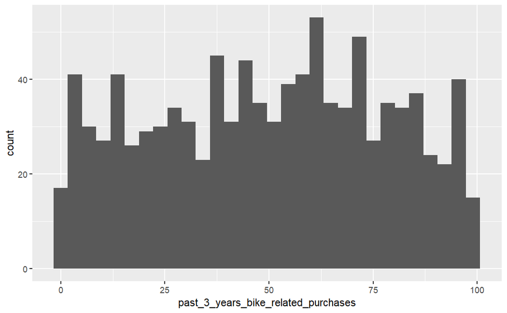

```r
ggplot(df_nc, aes(x=past_3_years_bike_related_purchases)) + geom_histogram()
```

NEWCUSTOMERLIST sheet: DOB

```r
stats_date(df_nc["DOB"])
```

| Variable | Value |
| --- | --- |
| Number of Rows | 1000 |
| Number of NAs | 71 |
| Number of Duplicates | 92 |
| Number of Uniques | 908 |

```r
min <- min(df_nc$DOB, na.rm=TRUE)
max <- max(df_nc$DOB, na.rm = TRUE)
data.frame(min, max)
```

| min | max |
| --- | --- |
| 1938-06-08 | 2002-02-27 |

```r
NA
```

```
Warning: Removed 71 rows containing non-finite values (stat_bin).
```

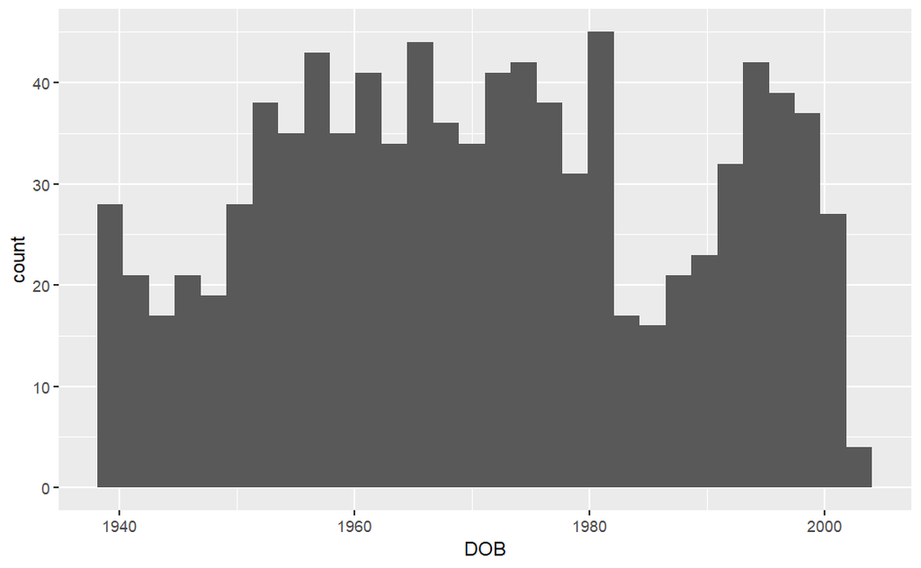

```r
ggplot(df_nc, aes(x=DOB)) + geom_histogram()
```

NEWCUSTOMERLIST sheet: job_title

```r
stats_cat(df_nc["job_title"])
```

| Variable | Value |
| --- | --- |
| Number of Rows | 1000 |
| Number of NAs | 106 |
| Number of Duplicates | 815 |
| Number of Uniques | 185 |

```r
unique <- unique(df_nc["job_title"])
unique <- unique[order(unique["job_title"]),]
pull(unique, job_title)
```

```
  [1] "Account Coordinator"                  "Account Executive"                    "Account Representative I"
  [4] "Account Representative II"            "Account Representative III"           "Account Representative IV"
  [7] "Accountant I"                         "Accountant II"                        "Accountant III"
 [10] "Accountant IV"                        "Accounting Assistant I"               "Accounting Assistant II"
 [13] "Accounting Assistant III"             "Accounting Assistant IV"              "Actuary"
 [16] "Administrative Assistant I"           "Administrative Assistant II"          "Administrative Officer"
 [19] "Analog Circuit Design manager"        "Analyst Programmer"                   "Assistant Manager"
 [22] "Assistant Media Planner"              "Assistant Professor"                  "Associate Professor"
 [25] "Automation Specialist I"              "Automation Specialist II"             "Automation Specialist III"
 [28] "Automation Specialist IV"             "Biostatistician IV"                   "Budget/Accounting Analyst I"
 [31] "Budget/Accounting Analyst II"         "Budget/Accounting Analyst III"        "Budget/Accounting Analyst IV"
 [34] "Business Systems Development Analyst" "Chemical Engineer"                    "Chief Design Engineer"
 [37] "Civil Engineer"                       "Clinical Specialist"                  "Community Outreach Specialist"
 [40] "Compensation Analyst"                 "Computer Systems Analyst I"           "Computer Systems Analyst II"
 [43] "Computer Systems Analyst III"         "Computer Systems Analyst IV"          "Cost Accountant"
```

[output cut: 47 more lines]

```r
table <- as.data.frame(table(df_nc["job_title"]))
table <- table[order(-table["Freq"]),]
table
```

|  | Var1 | Freq |
| --- | --- | --- |
| 24 | Associate Professor | 15 |
| 66 | Environmental Tech | 14 |
| 147 | Software Consultant | 14 |
| 36 | Chief Design Engineer | 13 |
| 21 | Assistant Manager | 12 |
| 22 | Assistant Media Planner | 12 |
| 45 | Cost Accountant | 12 |
| 145 | Senior Sales Associate | 12 |
| 178 | VP Sales | 12 |
| 2 | Account Executive | 11 |

[output cut: 174 more lines]

NEWCUSTOMERLIST sheet: job_industry_category

```r
stats_cat(df_nc["job_industry_category"])
```

| Variable | Value |
| --- | --- |
| Number of Rows | 1000 |
| Number of NAs | 0 |
| Number of Duplicates | 990 |
| Number of Uniques | 10 |

```r
unique(df_nc["job_industry_category"])
```

| job_industry_category |
| --- |
| Manufacturing |
| Property |
| Financial Services |
| Entertainment |
| Retail |
| IT |
| Telecommunications |
| Health |
| n/a |
| Argiculture |

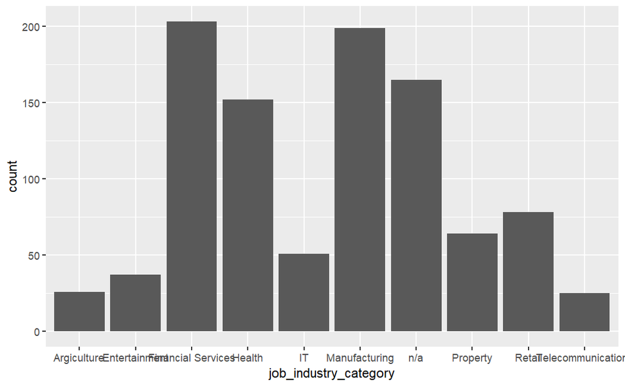

```r
ggplot(df_nc, aes(x=job_industry_category)) + geom_bar()
```

NEWCUSTOMERLIST sheet:

```r
stats_cat(df_nc["wealth_segment"])
```

| Variable | Value |
| --- | --- |
| Number of Rows | 1000 |
| Number of NAs | 0 |
| Number of Duplicates | 997 |
| Number of Uniques | 3 |

```r
NA
```

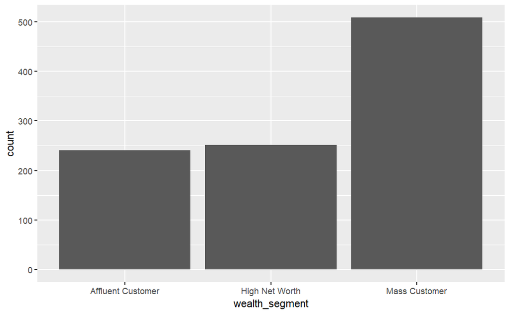

```r
ggplot(df_nc, aes(x=wealth_segment)) + geom_bar()
```

NEWCUSTOMERLIST sheet: deceased_indicator

```r
stats_cat(df_nc["deceased_indicator"])
```

| Variable | Value |
| --- | --- |
| Number of Rows | 1000 |
| Number of NAs | 0 |
| Number of Duplicates | 999 |
| Number of Uniques | 1 |

NEWCUSTOMERLIST sheet: owns_car

```r
stats_cat(df_nc["owns_car"])
```

| Variable | Value |
| --- | --- |
| Number of Rows | 1000 |
| Number of NAs | 0 |
| Number of Duplicates | 998 |
| Number of Uniques | 2 |

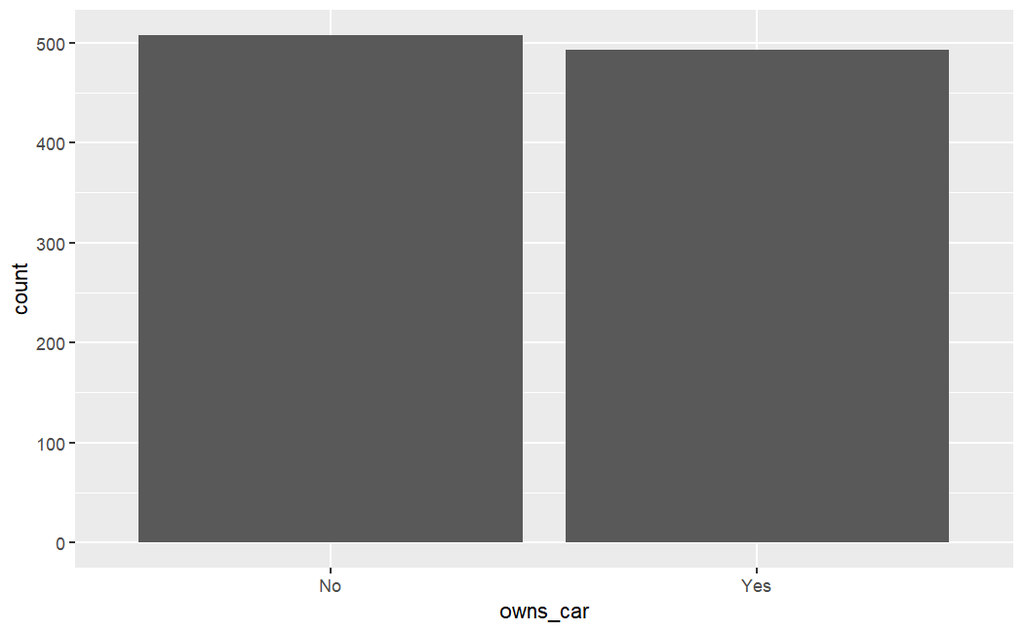

```r
ggplot(df_nc, aes(x=owns_car)) + geom_bar()
```

NEWCUSTOMERLIST sheet:

```r
stats_num(df_nc["tenure"])
```

| Variable | Value |
| --- | --- |
| Number of Rows | 1000 |
| Min | 0 |
| Max | 22 |
| Number of NAs | 0 |
| Number of Duplicates | 977 |
| Number of Uniques | 23 |

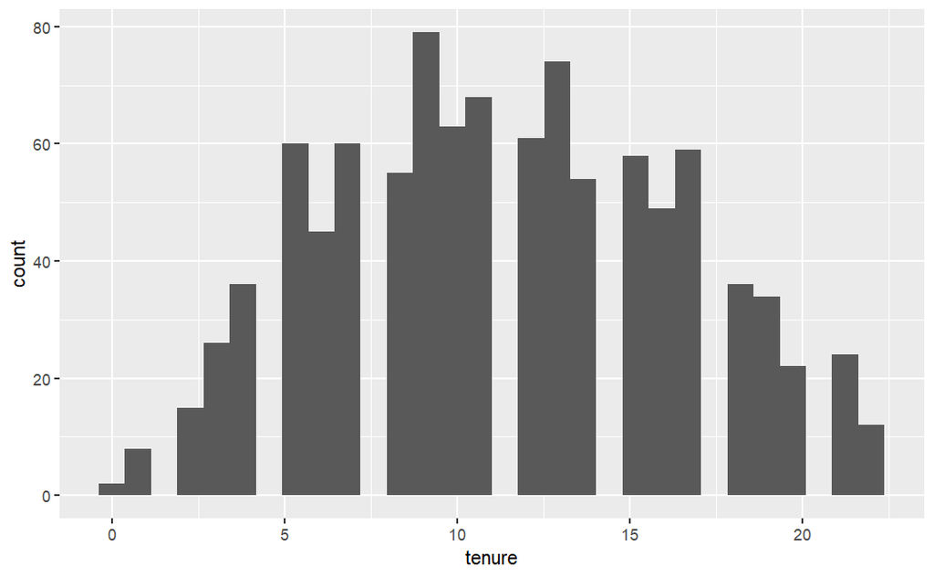

```r
ggplot(df_nc, aes(x=tenure)) + geom_histogram()
```

```r
table <- as.data.frame(table(df_nc["tenure"]))
table <- table[order(table["Freq"]),]
table
```

|  | Var1 | Freq |
| --- | --- | --- |
| 1 | 0 | 2 |
| 2 | 1 | 8 |
| 23 | 22 | 12 |
| 3 | 2 | 15 |
| 21 | 20 | 22 |
| 22 | 21 | 24 |
| 4 | 3 | 26 |
| 20 | 19 | 34 |
| 5 | 4 | 36 |
| 19 | 18 | 36 |

[output cut: 13 more lines]

NEWCUSTOMERLIST sheet: address

```r
stats_cat(df_nc["address"])
```

| Variable | Value |
| --- | --- |
| Number of Rows | 1000 |
| Number of NAs | 0 |
| Number of Duplicates | 0 |
| Number of Uniques | 1000 |

NEWCUSTOMERLIST sheet: post_code

```r
stats_cat(df_nc["postcode"])
```

| Variable | Value |
| --- | --- |
| Number of Rows | 1000 |
| Number of NAs | 0 |
| Number of Duplicates | 478 |
| Number of Uniques | 522 |

```r
# Check if there is a non-numeric value in a numeric column
vec <- pull(df_nc, postcode)
sum((is.na(as.numeric(as.character(vec)))))
```

```
[1] 0
```

NEWCUSTOMERLIST sheet: state

```r
stats_cat(df_nc["state"])
```

| Variable | Value |
| --- | --- |
| Number of Rows | 1000 |
| Number of NAs | 0 |
| Number of Duplicates | 997 |
| Number of Uniques | 3 |

```r
unique(df_nc["state"])
```

| state |
| --- |
| QLD |
| NSW |
| VIC |

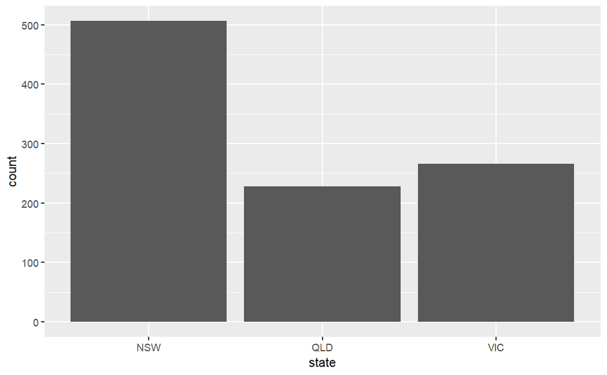

```r
ggplot(df_nc, aes(x=state)) + geom_bar()
```

NEWCUSTOMERLIST sheet: country

```r
stats_cat(df_nc["country"])
```

| Variable | Value |
| --- | --- |
| Number of Rows | 1000 |
| Number of NAs | 0 |
| Number of Duplicates | 999 |
| Number of Uniques | 1 |

NEWCUSTOMERLIST sheet: property_valuation

```r
stats_num(df_nc["property_valuation"])
```

| Variable | Value |
| --- | --- |
| Number of Rows | 1000 |
| Min | 1 |
| Max | 12 |
| Number of NAs | 0 |
| Number of Duplicates | 988 |
| Number of Uniques | 12 |

```r
# Check if there is a non-numeric value in a numeric column
vec <- pull(df_nc, property_valuation)
sum((is.na(as.numeric(as.character(vec)))))
```

```
[1] 0
```

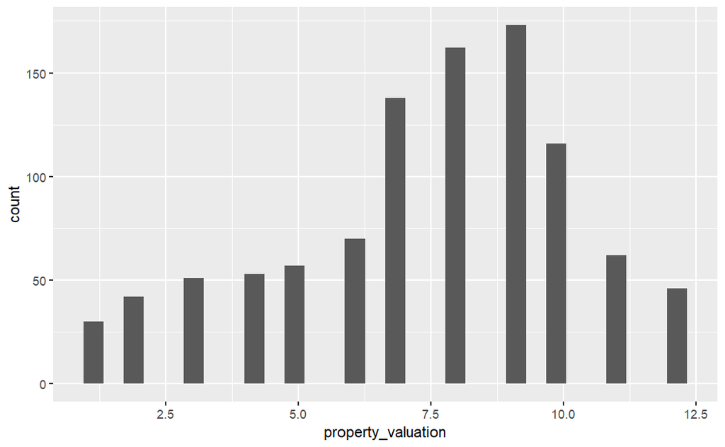

```r
ggplot(df_nc, aes(x=property_valuation)) + geom_histogram()
```

NEWCUSTOMERLIST sheet: rank

```r
stats_num(df_nc["Rank"])
```

| Variable | Value |
| --- | --- |
| Number of Rows | 1000 |
| Min | 1 |
| Max | 1000 |
| Number of NAs | 0 |
| Number of Duplicates | 676 |
| Number of Uniques | 324 |

```r
table <- as.data.frame(table(df_nc["Rank"]))
table <- table[order(-table["Freq"]),]
table
```

|  | Var1 | Freq |
| --- | --- | --- |
| 246 | 760 | 13 |
| 88 | 259 | 12 |
| 48 | 133 | 9 |
| 125 | 386 | 9 |
| 145 | 455 | 9 |
| 292 | 904 | 9 |
| 103 | 312 | 8 |
| 171 | 536 | 8 |
| 228 | 700 | 8 |
| 265 | 820 | 8 |

[output cut: 314 more lines]

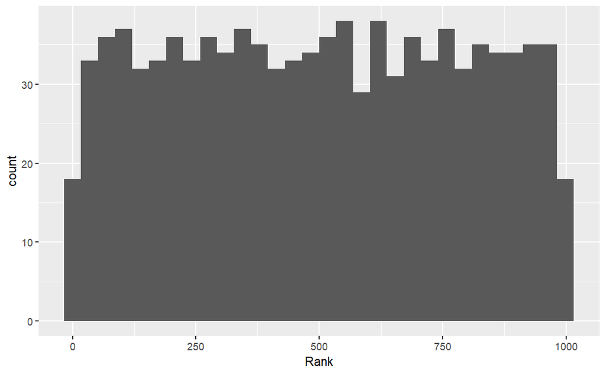

```r
ggplot(df_nc, aes(x=Rank)) + geom_histogram()
```

```r
vec <- pull(df_nc, Rank)
sum((is.na(as.numeric(as.character(vec)))))
```

```
[1] 0
```

NEWCUSTOMERLIST sheet: Value

```r
stats_num(df_nc["Value"])
```

| Variable | Value |
| --- | --- |
| Number of Rows | 1000.00000 |
| Min | 0.34000 |
| Max | 1.71875 |
| Number of NAs | 0.00000 |
| Number of Duplicates | 676.00000 |
| Number of Uniques | 324.00000 |

```r
vec <- pull(df_nc, Value)
sum((is.na(as.numeric(as.character(vec)))))
```

```
[1] 0
```